# HW5 notebook

Here is the first method for overlaying shape data on a raster.

Use the following packages (install them first), then use them via the library() call: tmap, tmaptools, rgdal, sp, OpenStreetMap, osmdata

These calls are useful: readOGR(), tmaptools::read_osm(), tm_shape(), tm_raster(), tm_dots()

1. readOGR() your shapefile, store it in a var
2. read_osm() the bbox of #1 above, store it in a var
3. do tm_shape() on #2 + tm_raster() + tm_shape() on #1 + tm_dots() to specify point color and size

First I install the necessary packeges and load them. I set my working directory to be where mygeodata file is saved.

```r
setwd("C:/Users/gelia/Documents/R")
```

```
The working directory was changed to C:/Users/gelia/Documents/R inside a notebook chunk. The working directory will be reset when the chunk is finished running. Use the knitr root.dir option in the setup chunk to change the working directory for notebook chunks.
```

```r
install.packages("tmap")
install.packages("tmaptools")
install.packages("rgdal")
install.packages("sp")
install.packages("OpenStreetMap")
install.packages("osmdata")
library(tmap)
library(tmaptools)
library(rgdal)
library(sp)
library(OpenStreetMap)
library(osmdata)
```

I read the .shp file after converting my kml file from homework3.

I use red color and size 6 to match the example provided the HW page.

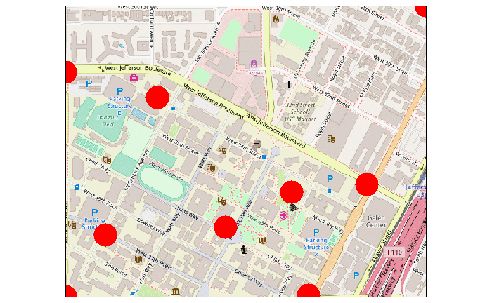

```r
shape <- readOGR("C:/Users/gelia/Documents/R/mygeodata" ,"hw5")
shape2 <- tmaptools::read_osm(shape)
tm_shape(shape2) + tm_raster() + tm_shape(shape) + tm_dots(col = "red",size = 6)
```

And here’s the second.

Use these packages: PBSmapping, ggmap And these calls: importShapefile(), as.data.frame(), get_map(), ggmap(), geom_point()

1. importShapefile() into a var
2. convert it (#1 above) to a dataframe, store it in a var
3. get_map() with a location that’s in your collection of (lat,long), store it in a var
4. do ggmap() on #3, + geom_point() on #2

Frist I will install the necessary packages and load them.

```r
install.packages("PBSmapping")
install.packages("ggmap")
library(PBSmapping)
library(ggmap)
```

The C:/Users/gelia/Documents/R/mygeodata is where my .shp file is and where all the files are saved after the conversion from kml using the website provided.

I set my working directory where my file is saved so I can import it using importShapeFile().

The files in the folder mygeodata have name hw5, that’s why I used fn=hw5(filename = hw5). I used as my location Tommy Trojan, in other word the most ‘central’ point on the map. I chose it so that as many points as possible would be visible on the map.

```r
setwd("C:/Users/gelia/Documents/R/mygeodata")
```

```
The working directory was changed to C:/Users/gelia/Documents/R/mygeodata inside a notebook chunk. The working directory will be reset when the chunk is finished running. Use the knitr root.dir option in the setup chunk to change the working directory for notebook chunks.
```

```r
myShape <- importShapefile(fn = 'hw5')
```

```
Checking rgeos availability: TRUE
```

[figure not shown]

```r
myShape2 <- as.data.frame(myShape)
location <- get_map(location = c(long = -118.2854 , lat = 34.02056), zoom = 16)
ggmap(location) + geom_point(data = myShape2 ,aes(x = X, y = Y),col = 'orange',size = 3)
```